# Форматирование программного кода

В крупных компаниях разработка программного кода носит коллективный характер. По этой причине команды стараются выработать единый стиль программирования и формат написания программных кодов, чтобы каждый следующий разработчик тратил минимальное время на вхождение, привыкание и понимание нового для него участка программного кода.

Форматирование программного кода используется для приведения его к определенному стилю. Основной идеей является расположение текстов программных кодов так, чтобы отчетливо было видно открывающие и закрывающие фигурные скобки тела класса, функции, ветвления или цикла. Таким образом удается локализовать область дальнейших изысканий.

Все названия пространств имен, классов, параметров, функций, расположенных на одном иерархическом уровне, подлежат форматированию путем отступов от нулевой части страницы. Горячее сочетание клавиш "(Ctrl+K)+(Ctrl+F)". Попробуйте... Привожу два скриншота " до и после".

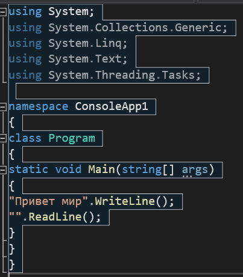

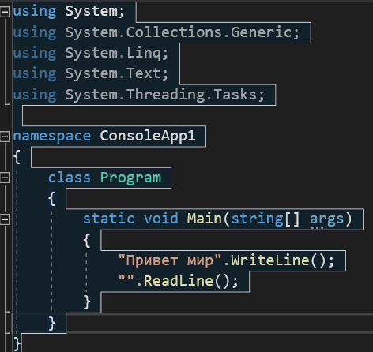

# Нотации в программировании: верблюд, змея, шашлык и другие

https://skillbox.ru/media/code/notatsii-v-programmirovanii/

### Верблюжья нотация (сamel case, camelCase)

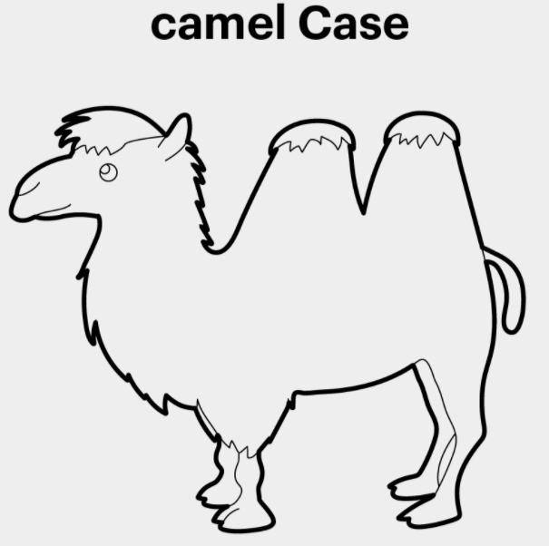

Первое слово пишется со строчной буквы, следующие — с заглавной, разделителей между составными частями нет. Торчащие посреди итогового названия заглавные буквы напомнили кому-то горбы верблюда — так возникло название нотации.

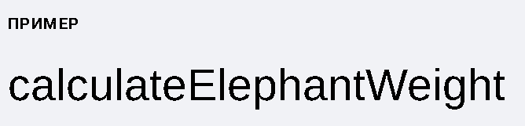

# Нотация Паскаля (Pascal case, PascalCase)

Тот же camelCase, но все слова, даже первое, начинаются с заглавной буквы.

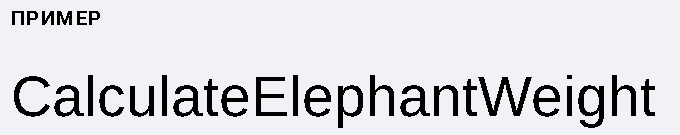

В таком стиле часто именуют классы (в Java, Python, JavaScript), а в программной платформе .NET — ещё и переменные.

Стиль так называется вовсе не в честь Блеза Паскаля. Pascal case стал известным, благодаря почти забытому языку Паскаль — в нём так именовались переменные, процедуры и функции.

А вот язык Паскаль, кстати, назван Никлаусом Виртом, его создателем, как раз в честь великого француза.

Иногда Pascal case называют upper camel case или, наоборот, camel case называют low Pascal case.